# Introduction to Statistics

Bennett Kleinberg

Week 13

## Week 13

De binomiaaltest

- Deel 1: De logica van de binomiaaltest
- Deel 2: Hypothesetoetsing met de binomiaaltest

Deel 1: De logica van de binomiaaltest

## Terug naar week 3

Binomiale data met 2 mogelijke uitkomsten A en B.

- $P(A) = p$
- $P(B) = q$

Omdat we maar twee uitkomsten hebben, is $P(A) + P(B) = 1$, dus

- $p + q = 1$
- $q = 1-p$

## Eigenschappen van de binomiale verdeling

Formeel beschreven door twee parameters:

$X \sim B(n, p)$

- $n$ = aantal trials (bv. 10)
- $p$ = kans op succes

Opmerking: als $n=1$ wordt de binomiale verdeling de **Bernoulli verdeling** genoemd.

## De binomiale benadert de normale verdeling

Als $pn$ en $qn$ minstens 10 zijn:

## Voorbeeld

Raden op het examen:

- 40 examenvragen: $n=40$
- veronderstel dat elk een 4-keuze MC vraag is:
  - juist geraden: $p=0.25$
  - foute gok: $q=1-p=1-0.25=0.75$

De binomiale verdeling heeft dan:

- $\mu = pn = 0.25*40 =10$
- $\sigma = \sqrt{npq} = \sqrt{40*0.25*0.75} =2.74$

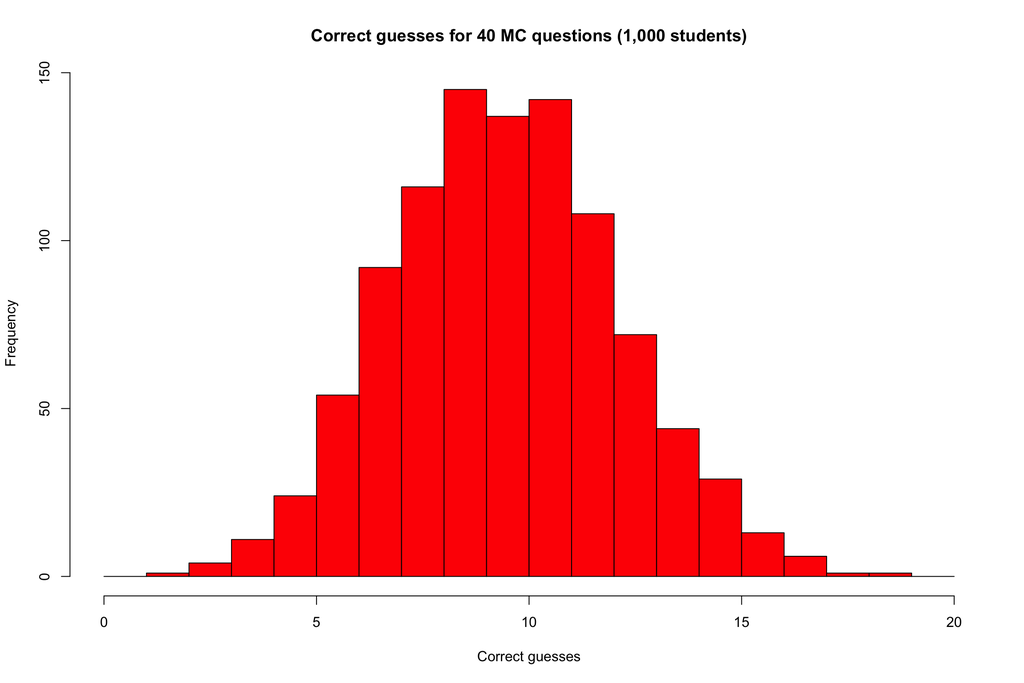

## Now what?

- we kunnen de binomiale verdeling beschrijven met $\mu$ en $\sigma$
- d.w.z. we kunnen zeggen wat we zouden verwachten *onder een gegeven verdeling*

Logica voor het testen van hypothesen: we beoordelen waar een nieuw datapunt zich in de verwachte verdeling bevindt.

- Als een steekproef $X$ zich in een *redelijk* deel van de verwachte verdeling bevindt –> verwerpen we de nulhypothese niet
- Als een steekproef $X$ in het *onwaarschijnlijke* gebied van de verwachte verdeling ligt –> verwerpen we **wel** de nulhypothese

## De z-score

Eenvoudige vorm:

$z=\frac{X-\mu}{\sigma}$ (d.w.z. hoeveel $\sigma$ de waarde $X$ verwijderd is van het gemiddelde $\mu$)

We substitueren:

$z=\frac{X-pn}{\sqrt{npq}}$

(Alternatieve versie uit het boek: $z=\frac{\frac{X}{n}-p}{\sqrt{(\frac{pq}{n})}}$)

## Logica van de “binomiale z-test”

- we weten wat we *onder de nul* kunnen verwachten (b.v. als we gewoon geraden hebben of als de dingen willekeurig waren of niet verschillend)
- we verzamelen data en berekenen hoeveel een nieuwe steekproef daarvan afwijkt
- en verkrijgen dan een waarschijnlijkheid van het vinden van die waarde onder de nul (*dit is weer significantie testen territorium*)

## Twee manieren om waarschijnlijkheden te verkrijgen

1. Via de z-score:
   - bereken $z$
   - vind staartwaarschijnlijkheden
2. Via de directe formule

Beide leveren dezelfde conclusies op!

## De directe formule

$P(k |n,p) ={n \choose k} p^k(1-p)^{n-k}$, met

${n \choose k} = \frac{n!}{k!(n-k)!}$ (k=aantal successen)

*Note:* $n!$ leest als “n factorial” en is gedefinieerd als –> $3! = 3*2*1 = 6$

**Verschil:** de z-score manier vertrouwt op de normale benadering (die alleen geldt voor $pn=qn$ ten minste 10)

Deel 2: Hypothesetoetsing met de binomiaaltest

## Scenario 1

Een student maakt een proefexamen statistiek:

- $n=10$ vragen
- elk met 4 MC-opties, dus $p=0.25$

Ze beantwoordt 5 vragen juist. Wat is de kans dat ze dit bereikt heeft *als ze gewoon* gegokt had?

## Stapsgewijs

We kunnen de normale benadering niet gebruiken!

$P(k |n,p) ={n \choose k} p^k(1-p)^{n-k}$, met ${n \choose k} = \frac{n!}{k!(n-k)!}$

Anders geformuleerd: we willen de kans op $k=5$ juiste gissingen berekenen gegeven $n=10$ trials elk met een kans op succes van $p=0.25$.

## Stapsgewijs

$P(k |n,p) ={n \choose k} p^k(1-p)^{n-k}$, met ${n \choose k} = \frac{n!}{k!(n-k)!}$

Stap 1:

${n \choose k} = \frac{n!}{k!(n-k)!} = \frac{10!}{5!(10-5)!}= \frac{10!}{5!(5!)}= \frac{3628800}{120^2}=252$

Stap 2:

$P(k=5 |n=10,p=0.25) =252 * 0.25^5*(1-0.25)^{10-5}$, dus

$P(k=5 |n=10,p=0.25) = 252 * 0.25^5*(0.75)^5 = 0.0584$

De kans op 5 juiste gissingen in een 10-vragen 4-MC examen is 0.06 (~5.84%).

## Scenario 2

We vergelijken een KI-gebaseerd diagnostisch hulpmiddel met beslissingen genomen door een menselijke psycholoog:

- dossiers van 1000 patiënten (waarvan de psycholoog vond dat 400 een stoornis hadden)
- het KI-systeem neemt nu in 430 gevallen een juiste beslissing (stoornis vs geen stoornis)

Vraag: is het KI-systeem beter dan gewoon gissen?

## Formaliseren van het probleem

- 1000 patiëntendossiers: $n=1000$
- de “grondwaarheid” is 400/1000 (bepaald door een menselijke psycholoog): $p=0.40$
- aantal successen: $k=430$

We kunnen nu de normale benadering gebruiken aangezien $pn=400$ en $qn = 600$.

Dus:

- $\mu = pn = 0.4*1000=400$
- $\sigma = \sqrt{npq} = \sqrt{1000*0.4*0.6}=15.49$

## Hypotheses

Het KI-systeem is gewoon aan het gissen:

$H_0: p=0.40$ en omgekeerd $q=0.60$

versus.

$H_1: p > 0.40$

## Verwachte gokverdeling

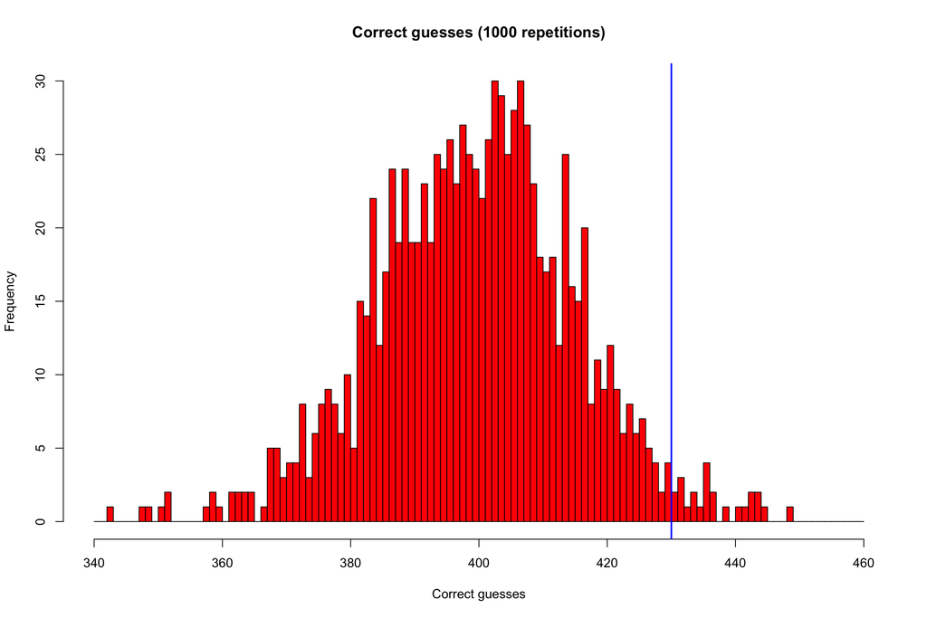

## Route 1: exacte kans

$P(k |n,p) ={n \choose k} p^k(1-p)^{n-k}$, met ${n \choose k} = \frac{n!}{k!(n-k)!}$

Step 1:

${n \choose k} = \frac{n!}{k!(n-k)!} = \frac{1000!}{430!(570)!}=...$

**MEESTAL NIET BEREKENBAAR.**

Dit is waar en waarom de z-score ons komt redden!

Route 1: exacte kans –> z-score

## Route 2: z-score

$z=\frac{\frac{X}{n}-p}{\sqrt{(\frac{pq}{n})}}$

dus:

$z=\frac{\frac{430}{1000}-0.40}{\sqrt{(\frac{0.40*0.60}{1000})}} = \frac{0.03}{\sqrt{0.00024}}=1.94$

Opmerking: de “standaard” z-score zou resulteren in

$z=\frac{X-pn}{\sqrt{npq}}=\frac{430-400}{\sqrt{240}}=\frac{30}{15.49}=1.94$

## Bepalen van de kans

We weten dat 430 correcte beslissingen (op 1000) met gokkans 0.40 zich vertaalt in een z-score van $z=1.94$

Laatste benodigde stap: *bepaal de staart proporties*

Opzoeking in tabel voor $z=1.94$ toont aan: *proportie in staart* voor $z=1.94$ is 0.0262.

De kans op 430 juiste beslissingen door toeval (in dit scenario) is 0.0262. Voor $\alpha=0.05$ zouden we $H_0$ verwerpen en concluderen dat het AI-systeem beter is dan gewoon gissen.

## In de live sessie

- voorbeelden van de binomiale test
- open vragen

## Recap

- speciaal geval van discrete data: binomiale data (slechts twee uitkomsten)
- voor grote steekproefgroottes benadert de binomiale verdeling de normale verdeling (zodat we de z-score test kunnen gebruiken)
- in andere gevallen hebben we de exacte kansformule nodig

## Volgende week

Proefexamen 2 (gebruik de tijd voor revisie - er zijn geen colleges in week 14)